# Analyse comparative des réseaux de collaboration entre les étudiants du cours BIO500 et les réseaux écologiques

Ariane Barrette, Mia Carrière, Laurie-Anne Cournoyer & Marie-Claude Mayotte

2023-04-22

# Résumé

# Introduction

Dans une communauté écologique, différentes espèces interagissent ensemble. L’interaction entre ces espèces peut mener à produire différents modèles de réseau. En effet, au sein des réseaux écologiques, l’organisation et la position des espèces dans la communauté peuvent être déterminées (Delmas et al. 2019). Les réseaux écologiques des espèces peuvent également s’appliquer à d’autres contextes. L’objectif principal de cet article vise à comparer les réseaux de collaboration entre les étudiants du cours de méthodes en écologie computationnelle à ceux des réseaux écologiques. L’atteinte de cet objectif permettra de mieux comprendre les différences entre les propriétés des réseaux des étudiants en écologie et celles des réseaux écologiques. Ainsi, pour notre projet, trois questions de recherches ont été élaborées : (1) « Peut-on observer un patron de centralité entre les étudiants d’une classe en analysant leurs interactions dans les travaux scolaires ? », (2) « Retrouve-t-on des patrons d’interactions entre les élèves basé sur leur formation préalable et leur année d’admission au baccalauréat ? », (3) « Comment les relations entre les élèves d’une classe varient-elles en fonction de leur région administrative ?.». Afin de répondre à ces différentes questions de recherches, une analyse collaborative sur la plateforme GitHub a été réalisé à l’aide de Rstudio.

# Méthode et résultats

Afin de répondre à ces questions de recherche, une campagne de collecte de données a été réalisée en collaboration avec tous les étudiants du cours de méthodes computationnelles afin de créer trois bases de données (collaboration, étudiant et cours). Afin d’analyser ces données, un projet collaboratif sur la plateforme GitHub a été créé. À partir de cette plateforme et par l’entremise de Rstudio, le nettoyage des données, la création des figures et du target ont été réalisés. En ce qui concerne le target, c’est la librairie RSQLite qui a été utilisée. Pour terminer, l’article a été réalisé à l’aide de Rmarkdown.

D’ailleurs, afin d’illustrer la centralité des étudiants, la figure 1 a été créée à l’aide des librairies htmlwidgets, webshot, ggplot2, igraph et fields de R. Elle représente le nombre de collaborations différentes effectuées par chaque étudiant. L’étudiant ayant réalisé le plus de collaborations s’attribuant le rang le plus élevée (le rang 162) et étant l’étudiant le plus central. Les figures 2 et 3 ont été réalisés à l’aide de la librairie gplots dans R. Elles représentent la moyenne du nombre de collaborations selon leur parcours éducatif et selon leur année d’entrée au baccalauréat. La barre la plus grande représente la catégorie ayant eu le plus de collaborations avec différents étudiants. La figure 4 représente les collaborations entre les étudiants en fonction de leur région native. Elle a été réalisée à l’aide des librairies leaflet et leaflegend de R. Les lignes les plus épaisses représentent les régions ayant eu le plus de collaborations entre-elles.

# Résultats

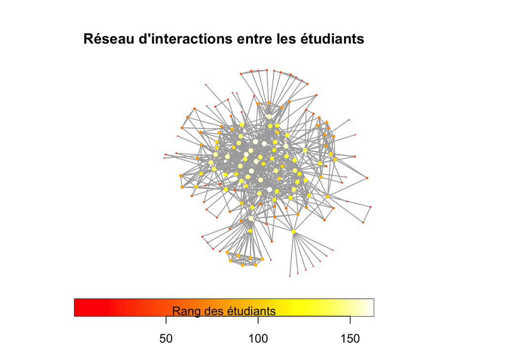

Figure 1 : Réseau d’interaction entre les étudiants. Les points blancs représentes les étudiants les plus centraux alors que les points rouges représentrent les étudiants les moins centraux, c’est-à-dire ceux qui ont collaboré avec le moins de mondes.

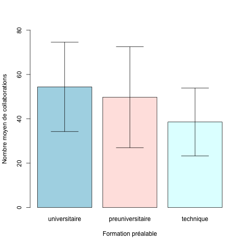

Figure 2 : Nombre de collaborations des différents élèves de méthodes computationnelles selon la formation préalable avant l’entrée au baccalauréat.La barre représente l’écart-type.

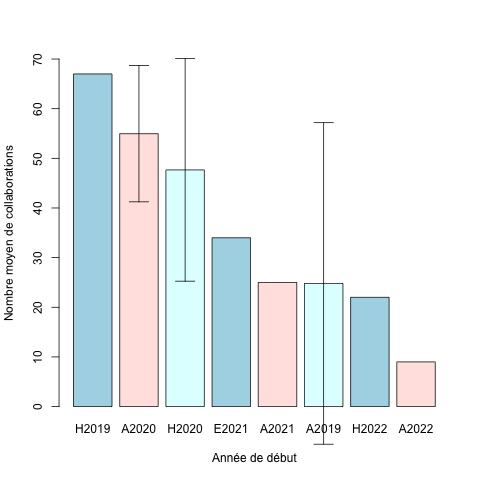

Figure 3: Nombre de collaborations des différents élèves de méthodes computationnelles selon l’année d’entrée au baccalauréat.

[figure not shown]

Figure 4 : Collaborations entre les différents élèves du cours de méthodes computationnelles selon leur région administratives d’origine.Les lignes représentent les collaborations entre deux élèves, plus la ligne est épaisse et plus il y a eu de collaborations entre ces deux régions.

# Discussion

## Centralité

La centralité est un concept important dans les réseaux écologiques puisqu’elle est souvent utiliser afin d’identifier les espèces « clés » du système (Cagua, Wootton, and Stouffer 2019). En effet, selon ce principe, les espèces participants dans plus de chaines sont plus susceptibles d’affecter l’abondance des autres espèces (Cagua, Wootton, and Stouffer 2019). De plus, elle peut apporter de l’information pour prédire quelle espèce, si elle venait à disparaître, aurait le plus grand impact sur la communauté (Cagua, Wootton, and Stouffer 2019). Toutefois, il faut apporter la nuance que la centralité ne parvient pas à identifier les espèces qui sont moins connectés, mais qui ont tout de même une grande capacité de contrôle sur la communauté (Cagua, Wootton, and Stouffer 2019). Dans le cas de cette expérience, il est premièrement possible d’observer un patron de centralité entre les étudiants en analysant leurs interactions dans les travaux scolaires. En effet, les étudiants ayant collaborés avec un grand nombre de personnes différentes sont représentés comme étant des étudiants centraux. En interagissant avec une grande partie du réseau, ces étudiants ont un impact significatif sur l’abondance des autres élèves, qui dans ce contexte peut être représentée par leurs notes scolaires, établissant ainsi un lien avec les systèmes écologiques. Par ailleurs, ce réseau prend seulement en compte les interactions entre les élèves de la classe. Toutefois, plusieurs élèves ont interagi, au cours de leur baccalauréat, avec des étudiants ne se sont pas dans ce cours. Par conséquent, ces étudiants font donc partie d’un autre réseau et la centralité ne nous permet donc pas d’évaluer adéquatement leur importance.

## Patrons d’interactions

Tous les réseaux écologiques, même les plus hétérogènes, présentent certaines structures et regroupements d’interactions entre les nœuds (Delmas et al. 2019; Milo et al. 2002). En fait, il existe 13 patrons possibles pour une interaction à trois nœuds chacun représentant une relation différente (Delmas et al. 2019; Milo et al. 2002). Par exemple, il y a la concurrence entre A et B pour la ressource partagée C (A -> C <- B) ou une chaine alimentaire où A prédate B et B prédate C (A -> B -> C) (Delmas et al. 2019; Milo et al. 2002). En se basant sur la formation préalable des étudiants, on peut observer que les étudiants ayant une formation universitaire sont plus susceptible de travailler avec un plus grand nombre de personnes différentes que les personnes ayant une formation technicienne. De plus, les étudiants qui sont rentrés au baccalauréat en écologie en hiver 2019 ont travaillé avec un plus grand nombre de personnes que ceux des autres sessions d’admission et cela malgré qu’ils soient beaucoup moins que les étudiants à être rentrés à l’automne 2020. Cela est assez logique puisque ces étudiants ont un parcours différent et par conséquent, ils doivent souvent collaborés avec d’autres cohortes. Il est donc possible d’observer certains patrons d’interactions entre les élèves.

Toutefois, ces résultats sont surtout préliminaires puisqu’ils ne tiennent pas compte de la proportion d’étudiants dans chaque catégorie. Par exemple, comme il y a moins d’étudiants qui ont une formation technicienne que pré-universitaire, il est logique qu’il possède un nombre d’interactions inférieurs aux autres catégories. Pour avoir un meilleur aperçu des regroupements, il faudrait pondérer les moyens de chaque catégorie.

## Connectivité des régions administratives

Pour assurer la survie des espèces, il est crucial d’évaluer leur connectivité entre les différentes zones géographiques (Baguette et al. 2013). En effet, la disparition d’une population locale peut précéder l’extinction de l’espèce dans son ensemble (Baguette et al. 2013). De plus, certaines espèces jouent un rôle central dans le réseau écologique, ce qui signifie que leur disparition peut entraîner des conséquences importantes sur d’autres espèces et sur la stabilité de l’écosystème (Baguette et al. 2013). Il est donc important de prendre en compte à la fois la connectivité des habitats et le rôle des espèces centrales pour maintenir la biodiversité (Baguette et al. 2013).

En observant les interactions entre les élèves, la région de Montréal apparaît comme la zone centrale la plus peuplée en termes d’étudiants, ce qui est cohérent étant donné qu’elle est la région la plus densément peuplée du Québec (Gouvernement du Canada 2022). De plus, la zone avec la dispersion la plus importante, caractérisée ici par les interactions entre les étudiants, se situe entre Montréal et Sherbrooke. Il semble y avoir un patron montrant que la majorité des étudiants, quelle que soit leur région administrative, ont tendance à interagir plus fréquemment avec les zones centrales telles que Montréal, Sherbrooke et Trois-Rivières, plutôt qu’avec les zones situées à proximité. Pour établir un parallèle avec le réseau écologique, cette observation pourrait être attribuée à la présence d’étudiants clés dans ces régions.

Bref, le réseaux étudiants ressemblent sur plusieurs points aux réseaux écologiques par sa centralité, ses patrons d’assemblages et par la connectivité des régions administratives.

##### Lien vers le github

https://github.com/mcmayotte/projet_bio500.git

# Bibliographie

Baguette, Michel, Simon Blanchet, Delphine Legrand, Virginie M. Stevens, and Camille Turlure. 2013. “Individual Dispersal, Landscape Connectivity and Ecological Networks.” *Biological Reviews* 88 (2): 310–26. https://doi.org/10.1111/brv.12000.

Cagua, Edgar Fernando, Kate L. Wootton, and Daniel B. Stouffer. 2019. “Keystoneness, Centrality, and the Structural Controllability of Ecological Networks.” *Journal of Ecology* 107 (4): 1779–90. https://doi.org/10.1111/1365-2745.13147.

Delmas, Eva, Mathilde Besson, Marie-Hélène Brice, Laura A. Burkle, Giulio V. Dalla Riva, Marie-Josée Fortin, Dominique Gravel, et al. 2019. “Analysing Ecological Networks of Species Interactions.” *Biological Reviews* 94 (1): 16–36. https://doi.org/10.1111/brv.12433.

Gouvernement du Canada, Statistique Canada. 2022. “Les Municipalités Canadiennes Avec Les Croissances Et Les Décroissances Les Plus Rapides de 2016 à 2021.” https://www12.statcan.gc.ca/census-recensement/2021/as-sa/98-200-x/2021001/98-200-x2021001-fra.cfm.

Milo, R., S. Shen-Orr, S. Itzkovitz, N. Kashtan, D. Chklovskii, and U. Alon. 2002. “Network Motifs: Simple Building Blocks of Complex Networks.” *Science* 298 (5594): 824–27. https://doi.org/10.1126/science.298.5594.824.